# Assignment 2

Gabriela Serrano Echenagucia

2022 February 15

# **Logistic Regression**

```r
# Load the dataset "breast-cancer-wisconsin.data"
BC = read.csv("~/Library/Mobile Documents/com~apple~CloudDocs/Desktop/Univ Miami/6th Semester - SPRING 2022/CSC 597/Assignments/Datasets/Classification/breast-cancer-wisconsin.data")

# Assign names ot the columns
colnames(BC) <- c("sample.num","clump.thickness","uniformity.size","uniformity.shape","marginal.adh","single.size","nuclei","chromatin","nucleoli","mitoses","tumor")

# Missing values are represented with '?' char. So, replace with NA
BC[BC == '?'] <- NA

# Omit missing values
BC = na.omit(BC)

# For some reason R was reading column 7 as class: "char". So, change everything to numeric
BC = as.data.frame(apply(BC, 2, as.numeric))

# Convert 2 and 4 to 0 and 1, respectively
# 2 = 0 = benign
BC$tumor[BC$tumor=="2"] <- 0
# 4 = 1 = malign
BC$tumor[BC$tumor=="4"] <- 1

# Convert tumor (classification variable) to a factor
BC$tumor <- as.factor(BC$tumor)

# We make sure that this is true: (0 = 0 = benign) and (1 = 1 = malign), for the predictions part
contrasts(BC$tumor)
```

```
  1
0 0
1 1
```

```r
#View(BC)
```

## 1. Use the appropriate functions to obtain descriptive information about the variables included in the dataset (paste or include a screenshot with the resulting information)

```r
# Displays names of the variables
names(BC)
```

```
 [1] "sample.num"       "clump.thickness"  "uniformity.size"  "uniformity.shape" "marginal.adh"
 [6] "single.size"      "nuclei"           "chromatin"        "nucleoli"         "mitoses"
[11] "tumor"
```

```r
# Displays dimension of the dataframe
dim(BC)
```

```
[1] 682  11
```

```r
# Descriptive information about the variables included in the dataset
summary(BC)
```

```
   sample.num       clump.thickness  uniformity.size  uniformity.shape  marginal.adh     single.size
 Min.   :   63375   Min.   : 1.000   Min.   : 1.000   Min.   : 1.000   Min.   : 1.000   Min.   : 1.000
 1st Qu.:  877454   1st Qu.: 2.000   1st Qu.: 1.000   1st Qu.: 1.000   1st Qu.: 1.000   1st Qu.: 2.000
 Median : 1171820   Median : 4.000   Median : 1.000   Median : 1.000   Median : 1.000   Median : 2.000
 Mean   : 1076833   Mean   : 4.441   Mean   : 3.154   Mean   : 3.218   Mean   : 2.833   Mean   : 3.236
 3rd Qu.: 1238741   3rd Qu.: 6.000   3rd Qu.: 5.000   3rd Qu.: 5.000   3rd Qu.: 4.000   3rd Qu.: 4.000
 Max.   :13454352   Max.   :10.000   Max.   :10.000   Max.   :10.000   Max.   :10.000   Max.   :10.000
     nuclei         chromatin         nucleoli         mitoses       tumor
 Min.   : 1.000   Min.   : 1.000   Min.   : 1.000   Min.   : 1.000   0:443
 1st Qu.: 1.000   1st Qu.: 2.000   1st Qu.: 1.000   1st Qu.: 1.000   1:239
 Median : 1.000   Median : 3.000   Median : 1.000   Median : 1.000
 Mean   : 3.548   Mean   : 3.446   Mean   : 2.872   Mean   : 1.604
 3rd Qu.: 6.000   3rd Qu.: 5.000   3rd Qu.: 4.000   3rd Qu.: 1.000
 Max.   :10.000   Max.   :10.000   Max.   :10.000   Max.   :10.000
```

## 2. Calculate the correlation between the different attributes (include the figure produced by R in your answer)

```r
# Correlation (without non-numeric column)
correlation = cor(BC[,-11])
correlation
```

```
                  sample.num clump.thickness uniformity.size uniformity.shape marginal.adh single.size
sample.num        1.00000000     -0.05631603     -0.04153886       -0.0423733  -0.06976771 -0.04875619
clump.thickness  -0.05631603      1.00000000      0.64293619        0.6539679   0.48817460  0.52389088
uniformity.size  -0.04153886      0.64293619      1.00000000        0.9071584   0.70678597  0.75341483
uniformity.shape -0.04237330      0.65396787      0.90715837        1.0000000   0.68573480  0.72231297
marginal.adh     -0.06976771      0.48817460      0.70678597        0.6857348   1.00000000  0.59433953
single.size      -0.04875619      0.52389088      0.75341483        0.7223130   0.59433953  1.00000000
nuclei           -0.09941125      0.59352382      0.69148676        0.7136609   0.67043411  0.58548894
chromatin        -0.06200157      0.55382454      0.75566349        0.7354603   0.66861322  0.61813466
nucleoli         -0.05082432      0.53440632      0.71917301        0.7177840   0.60289319  0.62874253
mitoses          -0.03803942      0.35109959      0.46060349        0.4410959   0.41873448  0.48045096
                      nuclei   chromatin    nucleoli     mitoses
sample.num       -0.09941125 -0.06200157 -0.05082432 -0.03803942
clump.thickness   0.59352382  0.55382454  0.53440632  0.35109959
uniformity.size   0.69148676  0.75566349  0.71917301  0.46060349
uniformity.shape  0.71366086  0.73546030  0.71778402  0.44109586
marginal.adh      0.67043411  0.66861322  0.60289319  0.41873448
single.size       0.58548894  0.61813466  0.62874253  0.48045096
nuclei            1.00000000  0.68068880  0.58402210  0.33900499
chromatin         0.68068880  1.00000000  0.66563761  0.34595718
nucleoli          0.58402210  0.66563761  1.00000000  0.43360218
mitoses           0.33900499  0.34595718  0.43360218  1.00000000
```

```r
# Create figure
pdf("Correlation-Figure2.pdf")
pairs(correlation)
dev.off()
```

## 3. Divide the input dataset into training and testing

### a. Split the datasets using 80% for training and 20% for testing

```r
# Split
dt = sort(sample(nrow(BC), nrow(BC)*.8))
train = BC[dt,] # 545 obs out of 682 (or 80 %)
test = BC[-dt,] # 137 obs out of 682 (or 20 %)

# Training Set
train
```

|  | sample.num | clump.thickness | uniformity.size | uniformity.shape | marginal.adh | single.size | nuclei | chromatin | nucleoli | mitoses | tumor |
| --- | --- | --- | --- | --- | --- | --- | --- | --- | --- | --- | --- |
| 1 | 1002945 | 5 | 4 | 4 | 5 | 7 | 10 | 3 | 2 | 1 | 0 |
| 2 | 1015425 | 3 | 1 | 1 | 1 | 2 | 2 | 3 | 1 | 1 | 0 |
| 3 | 1016277 | 6 | 8 | 8 | 1 | 3 | 4 | 3 | 7 | 1 | 0 |
| 4 | 1017023 | 4 | 1 | 1 | 3 | 2 | 1 | 3 | 1 | 1 | 0 |
| 5 | 1017122 | 8 | 10 | 10 | 8 | 7 | 10 | 9 | 7 | 1 | 1 |
| 6 | 1018099 | 1 | 1 | 1 | 1 | 2 | 10 | 3 | 1 | 1 | 0 |
| 7 | 1018561 | 2 | 1 | 2 | 1 | 2 | 1 | 3 | 1 | 1 | 0 |
| 8 | 1033078 | 2 | 1 | 1 | 1 | 2 | 1 | 1 | 1 | 5 | 0 |
| 9 | 1033078 | 4 | 2 | 1 | 1 | 2 | 1 | 2 | 1 | 1 | 0 |
| 11 | 1036172 | 2 | 1 | 1 | 1 | 2 | 1 | 2 | 1 | 1 | 0 |

[output cut: 535 more lines]

```r
# Testing Set
test
```

|  | sample.num | clump.thickness | uniformity.size | uniformity.shape | marginal.adh | single.size | nuclei | chromatin | nucleoli | mitoses | tumor |
| --- | --- | --- | --- | --- | --- | --- | --- | --- | --- | --- | --- |
| 10 | 1035283 | 1 | 1 | 1 | 1 | 1 | 1 | 3 | 1 | 1 | 0 |
| 12 | 1041801 | 5 | 3 | 3 | 3 | 2 | 3 | 4 | 4 | 1 | 1 |
| 13 | 1043999 | 1 | 1 | 1 | 1 | 2 | 3 | 3 | 1 | 1 | 0 |
| 14 | 1044572 | 8 | 7 | 5 | 10 | 7 | 9 | 5 | 5 | 4 | 1 |
| 23 | 1059552 | 1 | 1 | 1 | 1 | 2 | 1 | 3 | 1 | 1 | 0 |
| 24 | 1065726 | 5 | 2 | 3 | 4 | 2 | 7 | 3 | 6 | 1 | 1 |
| 26 | 1066979 | 5 | 1 | 1 | 1 | 2 | 1 | 2 | 1 | 1 | 0 |
| 30 | 1071760 | 2 | 1 | 1 | 1 | 2 | 1 | 3 | 1 | 1 | 0 |
| 38 | 1091262 | 2 | 5 | 3 | 3 | 6 | 7 | 7 | 5 | 1 | 1 |
| 50 | 1110102 | 10 | 3 | 6 | 2 | 3 | 5 | 4 | 10 | 2 | 1 |

[output cut: 127 more lines]

### b. How many examples will be used for training and how many for testing?

For training 545 examples out of 682 and for testing 137 examples out of 682

## 4. Build a logistic regression model including all the input variables

```r
# Set seed to replicate results
set.seed(1)

# Logistic Regression
glm.model = glm(tumor ~., data = train, family = binomial)
summary(glm.model)
```

```
Call:
glm(formula = tumor ~ ., family = binomial, data = train)

Deviance Residuals:
    Min       1Q   Median       3Q      Max
-3.2481  -0.1129  -0.0582   0.0321   2.6972

Coefficients:
                   Estimate Std. Error z value Pr(>|z|)
(Intercept)      -8.942e+00  1.688e+00  -5.296 1.18e-07 ***
sample.num       -1.079e-06  1.190e-06  -0.907 0.364491
clump.thickness   5.576e-01  1.619e-01   3.444 0.000574 ***
uniformity.size  -4.329e-02  2.203e-01  -0.196 0.844229
uniformity.shape  3.589e-01  2.462e-01   1.458 0.144932
marginal.adh      2.442e-01  1.390e-01   1.757 0.078900 .
single.size       2.267e-01  1.766e-01   1.284 0.199200
nuclei            3.363e-01  1.011e-01   3.328 0.000874 ***
chromatin         4.600e-01  1.898e-01   2.424 0.015339 *
nucleoli          1.668e-01  1.221e-01   1.366 0.171838
mitoses           3.810e-01  3.295e-01   1.156 0.247564
---
Signif. codes:  0 ‘***’ 0.001 ‘**’ 0.01 ‘*’ 0.05 ‘.’ 0.1 ‘ ’ 1

(Dispersion parameter for binomial family taken to be 1)

    Null deviance: 708.46  on 544  degrees of freedom
Residual deviance:  81.80  on 534  degrees of freedom
AIC: 103.8

Number of Fisher Scoring iterations: 8
```

### a. How does the model perform? Provide the confusion matrix and the test error

Using Logistic Regression, the model performs very well. By computing the fraction for which the prediction was correct, we get a 0.9562044 which means around a 96% of accuracy in the prediction (and 4% of error).

```r
# Prediction
# Predict on test set (based on logistic model made with train set)
glm.pred = predict(glm.model, test, type = "response")

# Initialize vector with 137 elements
glm.probs = rep("0", 137)
glm.probs[glm.pred >0.5] = "1"

# Confusion matrix
table(glm.probs, test$tumor)
```

```
glm.probs  0  1
        0 89  4
        1  2 42
```

```r
# Compute the fraction for which the prediction was correct
mean(glm.probs==test$tumor)
```

```
[1] 0.9562044
```

```r
# Compute test error
mean(glm.probs!=test$tumor)
```

```
[1] 0.04379562
```

### b. Which predictors are statistically significant?

Bare Nuclei (nuclei) and Clump Thickness (clump.thickness) seem like the predictors that have a greater (most significant) impact in the prediction because they have the lowest p-values. P-values indicate if the coefficients from the independent variables are significantly different from zero. They are able to tell us if these ind. variables have weight in the mathematical relationship with the dependent variable.

In this problem, nuclei and clump.thickness seem to indicate a relationship with the type of tumor

## 6. Build an LDA model including all the input variables

```r
# Linear Discriminant Analysis
library(MASS)
lda.model = lda(tumor~., data = train)
lda.model
```

```
Call:
lda(tumor ~ ., data = train)

Prior probabilities of groups:
        0         1
0.6458716 0.3541284

Group means:
  sample.num clump.thickness uniformity.size uniformity.shape marginal.adh single.size   nuclei chromatin
0  1129497.2        2.957386        1.309659         1.431818     1.321023    2.085227 1.343750  2.028409
1   994716.2        7.186528        6.507772         6.538860     5.647668    5.269430 7.626943  6.005181
  nucleoli  mitoses
0 1.235795 1.079545
1 5.839378 2.632124

Coefficients of linear discriminants:
                           LD1
sample.num       -6.883123e-08
clump.thickness   1.932760e-01
uniformity.size   9.545418e-02
uniformity.shape  1.167662e-01
marginal.adh      3.670751e-02
single.size       1.086843e-01
nuclei            2.495295e-01
chromatin         1.277720e-01
nucleoli          1.047014e-01
mitoses          -2.952254e-02
```

### a. How does the model perform? Provide the confusion matrix and the test error

Using the LDA, we can see that the model performs very well. By computing the fraction for which the prediction was correct, we get a 0.9562044 which means around a 96% of accuracy in the prediction (and 4% of error).

```r
# Prediction
# Predict on test set (based on linear discriminant analysis made with train set)
lda.pred = predict(lda.model, test)
names(lda.pred)
```

```
[1] "class"     "posterior" "x"
```

```r
# Calculate performance metrics
lda.class=lda.pred$class

# Confusion matrix
table(lda.class, test$tumor)
```

```
lda.class  0  1
        0 89  4
        1  2 42
```

```r
# Compute the fraction for which the prediction was correct
mean(lda.class==test$tumor)
```

```
[1] 0.9562044
```

```r
# Compute test error
mean(lda.class!=test$tumor)
```

```
[1] 0.04379562
```

### b. Which predictors have more weight on the class?

Bare Nuclei (nuclei) and Clump Thickness (clump.thickness) seem like they are the predictors to have more weight on the class because they have highest coefficients. The coefficients describe the mathematical relationship between each independent variable and the dependent variable.

### c. Plot the linear discriminants

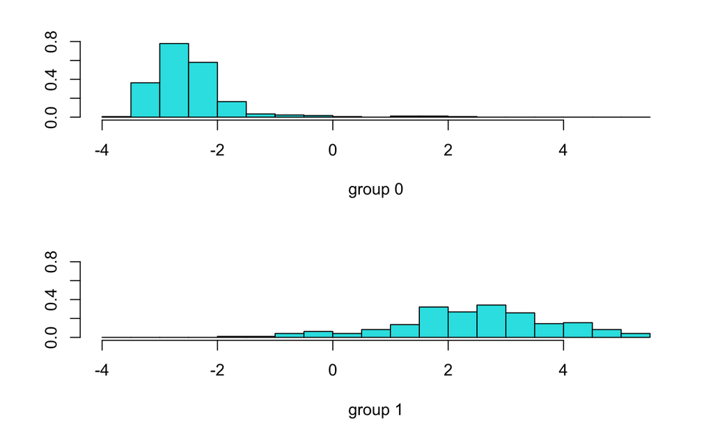

```r
# Linear discriminants
plot(lda.model)
```